# MATH2349 Semester 2, 2018, Assignment 3

Manuel Matthew Gunadi

```r
library(readxl)
library(rvest)
library(dplyr)
library(tidyr)
library(Hmisc)
library(forecast)
library(stringr)
library(outliers)
library(MVN)
library(infotheo)
library(caret)
library(mlr)
library(knitr)
```

# Executive summary:

## Read employment dataset

```r
Employment <- read_excel("ABS_Employment.xlsx", sheet = "Table 1.5", range = "A7:Q2305")
colnames(Employment)
```

```
##  [1] "X__1"    "X__2"    "MALES"   "X__3"    "X__4"    "X__5"    "X__6"
##  [8] "FEMALES" "X__7"    "X__8"    "X__9"    "X__10"   "PERSONS" "X__11"
## [15] "X__12"   "X__13"   "X__14"
```

```r
head(Employment)
```

```
## # A tibble: 6 x 17
##   X__1  X__2  MALES X__3  X__4  X__5  X__6  FEMALES X__7  X__8  X__9  X__~
##   <chr> <chr> <chr> <chr> <chr> <chr> <chr> <chr>   <chr> <chr> <chr> <ch>
## 1 SA2   SA2 ~ 2011~ 2012~ 2013~ 2014~ 2015~ 2011-12 2012~ 2013~ 2014~ 201~
## 2 Aust~ <NA>  9474~ 9578~ 9539~ 9591~ 9637~ 8532.1  8679~ 8691~ 8769~ 886~
## 3 New ~ <NA>  2916~ 2949~ 2952~ 2977~ 3039~ 2633.9~ 2725~ 2718~ 2726~ 278~
## 4 1010~ Brai~ 1.54~ 1.583 1.56~ 1.55~ 1.52~ 1.3979~ 1.49~ 1.476 1.415 1.5~
## 5 1010~ Kara~ 3.97~ 3.98~ 3.65~ 3.6   3.68~ 3.746   3.68~ 3.415 3.31~ 3.3~
## 6 1010~ Quea~ 5.21~ 5.22~ 4.88  4.78~ 4.92~ 4.5199~ 4.48~ 4.18~ 4.20~ 4.3~
## # ... with 5 more variables: PERSONS <chr>, X__11 <chr>, X__12 <chr>,
## #   X__13 <chr>, X__14 <chr>
```

- Inspect/ understand Employment data structure:
- get class, dimensions, names and classes of columns
- Data is a dataframe of characters: The frequency and income characters are actually numbers and will be converted to numerics. The first column contains characters of SA2 regions, which are suited as characters.

```r
class(Employment)
```

```
## [1] "tbl_df"     "tbl"        "data.frame"
```

```r
dim(Employment)
```

```
## [1] 2298   17
```

```r
names(Employment)
```

```
##  [1] "X__1"    "X__2"    "MALES"   "X__3"    "X__4"    "X__5"    "X__6"
##  [8] "FEMALES" "X__7"    "X__8"    "X__9"    "X__10"   "PERSONS" "X__11"
## [15] "X__12"   "X__13"   "X__14"
```

```r
sapply(Employment,class)
```

```
##        X__1        X__2       MALES        X__3        X__4        X__5
## "character" "character" "character" "character" "character" "character"
##        X__6     FEMALES        X__7        X__8        X__9       X__10
## "character" "character" "character" "character" "character" "character"
##     PERSONS       X__11       X__12       X__13       X__14
## "character" "character" "character" "character" "character"
```

## Read income dataset

```r
Income <- read_excel("ABS_Employment.xlsx", sheet = "Table 1.5", range = "R7:AF2305")
colnames(Income)
```

```
##  [1] "MALES"   "X__1"    "X__2"    "X__3"    "X__4"    "FEMALES" "X__5"
##  [8] "X__6"    "X__7"    "X__8"    "PERSONS" "X__9"    "X__10"   "X__11"
## [15] "X__12"
```

```r
head(Income)
```

```
## # A tibble: 6 x 15
##   MALES X__1  X__2  X__3  X__4  FEMALES X__5  X__6  X__7  X__8  PERSONS
##   <chr> <chr> <chr> <chr> <chr> <chr>   <chr> <chr> <chr> <chr> <chr>
## 1 2011~ 2012~ 2013~ 2014~ 2015~ 2011-12 2012~ 2013~ 2014~ 2015~ 2011-12
## 2 27769 28799 29537 29963 30410 17247   18000 18735 19676 20538 21918
## 3 28223 28862 29767 30279 30875 18608.5 18517 19627 20672 21645 22938
## 4 17914 17784 19553 21523 2332~ 13103   1223~ 12000 14439 1349~ 15123
## 5 35269 33944 3681~ 38015 34614 23000   26229 27863 28725 3022~ 28614
## 6 3078~ 32952 33250 34091 33009 24030.5 27010 29618 29580 29654 27234.5
## # ... with 4 more variables: X__9 <chr>, X__10 <chr>, X__11 <chr>,
## #   X__12 <chr>
```

- Inspect/ understand Income data structure:
- get class, dimensions and names of columns

```r
class(Income)
```

```
## [1] "tbl_df"     "tbl"        "data.frame"
```

```r
dim(Income)
```

```
## [1] 2298   15
```

```r
names(Income)
```

```
##  [1] "MALES"   "X__1"    "X__2"    "X__3"    "X__4"    "FEMALES" "X__5"
##  [8] "X__6"    "X__7"    "X__8"    "PERSONS" "X__9"    "X__10"   "X__11"
## [15] "X__12"
```

## Data tidying

- Clean employment data of all persons (male and female) into tidy format.
- First, subset the columns relating to ‘persons’
- Second, subset the rows which relate to observations for each region
- Gather the various columns containing year ranges into one long column
- convert into a data frame structure
- Convert “no. of jobs” variable from character to numeric, rounded to 3 digits.

```r
#1
all_employment <-Employment[,c(2,13:17)]
colnames(all_employment)[1:6] <- all_employment[1,1:6]
#2
all_employment <- all_employment[4:nrow(all_employment),]
#3
all_emp <- all_employment %>% gather("2011-12", "2012-13", "2013-14", "2014-15", "2015-16", key = "year", value = "no. of jobs")
#4
all_emp <- as.data.frame(all_emp)
#5
all_emp$`no. of jobs` <- round(as.numeric(all_emp$`no. of jobs`), digits = 3)
#6
head(all_emp)
```

```
##                          SA2 NAME    year no. of jobs
## 1                       Braidwood 2011-12       2.945
## 2                         Karabar 2011-12       7.719
## 3                      Queanbeyan 2011-12       9.732
## 4               Queanbeyan - East 2011-12       4.516
## 5               Queanbeyan Region 2011-12      12.794
## 6 Queanbeyan West - Jerrabomberra 2011-12      11.189
```

## Data tidying part2

*As with employment data, tidy into one long data frame with income converted to numeric (3 d.ps)

```r
#1
all_Income <- bind_cols(Employment[,2],Income);
colnames(all_Income)
```

```
##  [1] "X__2"    "MALES"   "X__1"    "X__21"   "X__3"    "X__4"    "FEMALES"
##  [8] "X__5"    "X__6"    "X__7"    "X__8"    "PERSONS" "X__9"    "X__10"
## [15] "X__11"   "X__12"
```

```r
all_Income <- all_Income[,c(1,12:16)]
colnames(all_Income)[1:6] <- all_Income[1,1:6]
#2
all_Income <- all_Income[4:nrow(all_Income),]
#3
all_Income <- all_Income %>% gather("2011-12", "2012-13", "2013-14", "2014-15", "2015-16", key = "year", value = "Income")
#4
all_Income <- as.data.frame(all_Income)
#5
all_Income$Income <- round(as.numeric(all_Income$Income), digits = 0)
#6
head(all_Income)
```

```
##                          SA2 NAME    year Income
## 1                       Braidwood 2011-12  15123
## 2                         Karabar 2011-12  28614
## 3                      Queanbeyan 2011-12  27234
## 4               Queanbeyan - East 2011-12  26528
## 5               Queanbeyan Region 2011-12  29999
## 6 Queanbeyan West - Jerrabomberra 2011-12  37290
```

## Merging employment and Income datasets

```r
Employ_income <- bind_cols(all_emp, Income = all_Income$Income)
```

## Filtering data and further tidying

- As we only have data from the 2016 census data, the most relevant time period for the employment figures is the 2015-2016 data set. Therefore, we filter the employment data for this time range.
- convert the year range, 2015-2016 into a single year, 2016, in numeric format.
- multiply the “no. of jobs” by 1000 as this data is thousands

```r
Employ_income <- Employ_income %>% filter(year == "2015-16")
Employ_income <- Employ_income %>% mutate(year = str_replace(year, "15-", ""))
Employ_income$year = as.numeric(Employ_income$year)
Employ_income$`no. of jobs` <- Employ_income$`no. of jobs` * 1000
head(Employ_income)
```

```
##                          SA2 NAME year no. of jobs Income
## 1                       Braidwood 2016        3063  17882
## 2                         Karabar 2016        7067  31950
## 3                      Queanbeyan 2016        9310  31491
## 4               Queanbeyan - East 2016        4480  29988
## 5               Queanbeyan Region 2016       14061  37092
## 6 Queanbeyan West - Jerrabomberra 2016       11356  39012
```

## Read mortgage dataset

- Read mortgage data from ABS: 2016 Census - Monthly Mortgage Repayments & dwellings location on census night
- The data is ABS census data from the 2016 Australian census. It was downloaded from TableBuilder (https://auth.censusdata.abs.gov.au/webapi/jsf/login.xhtml ) using a public account.
- The fields selected were: * all SA2s within NSW * monthly mortgage repayments by dwelling
- This data is under a creative commons licence.

```r
mortgage <- read_excel("NSW_SA2_MortgageRepayments.xlsx", range = "B9:X587")
head(mortgage)
```

```
## # A tibble: 6 x 23
##   X__1  `Nil repayments` `$1-$149` `$150-$299` `$300-$449` `$450-$599`
##   <chr>            <dbl>     <dbl>       <dbl>       <dbl>       <dbl>
## 1 SA2                 NA        NA          NA          NA          NA
## 2 Avoc~               17         8          12          17          14
## 3 Box ~               49        27          15          29          30
## 4 Calg~               27        12           7           8          12
## 5 Erin~               45        13          11          40          33
## 6 Gosf~               44        17          25          42          52
## # ... with 17 more variables: `$600-$799` <dbl>, `$800-$999` <dbl>,
## #   `$1,000-$1,199` <dbl>, `$1,200-$1,399` <dbl>, `$1,400-$1,599` <dbl>,
## #   `$1,600-$1,799` <dbl>, `$1,800-$1,999` <dbl>, `$2,000-$2,199` <dbl>,
## #   `$2,200-$2,399` <dbl>, `$2,400-$2,599` <dbl>, `$2,600-$2,999` <dbl>,
## #   `$3,000-$3,999` <dbl>, `$4,000-$4,999` <dbl>, `$5000 and over` <dbl>,
## #   `Not stated` <dbl>, `Not applicable` <dbl>, Total <dbl>
```

- Inspect/ understand mortgage data structure:
- The dataframe consists of characters: SA2 regions (matching the employment and income data column, SA2 region), mortgage replayment ranges (more suited to factors) and frequencies (more suited to numerics).

```r
class(mortgage)
```

```
## [1] "tbl_df"     "tbl"        "data.frame"
```

```r
dim(mortgage)
```

```
## [1] 578  23
```

```r
names(mortgage)
```

```
##  [1] "X__1"           "Nil repayments" "$1-$149"        "$150-$299"
##  [5] "$300-$449"      "$450-$599"      "$600-$799"      "$800-$999"
##  [9] "$1,000-$1,199"  "$1,200-$1,399"  "$1,400-$1,599"  "$1,600-$1,799"
## [13] "$1,800-$1,999"  "$2,000-$2,199"  "$2,200-$2,399"  "$2,400-$2,599"
## [17] "$2,600-$2,999"  "$3,000-$3,999"  "$4,000-$4,999"  "$5000 and over"
## [21] "Not stated"     "Not applicable" "Total"
```

```r
sapply(mortgage,class)
```

```
##           X__1 Nil repayments        $1-$149      $150-$299      $300-$449
##    "character"      "numeric"      "numeric"      "numeric"      "numeric"
##      $450-$599      $600-$799      $800-$999  $1,000-$1,199  $1,200-$1,399
##      "numeric"      "numeric"      "numeric"      "numeric"      "numeric"
##  $1,400-$1,599  $1,600-$1,799  $1,800-$1,999  $2,000-$2,199  $2,200-$2,399
##      "numeric"      "numeric"      "numeric"      "numeric"      "numeric"
##  $2,400-$2,599  $2,600-$2,999  $3,000-$3,999  $4,000-$4,999 $5000 and over
##      "numeric"      "numeric"      "numeric"      "numeric"      "numeric"
##     Not stated Not applicable          Total
##      "numeric"      "numeric"      "numeric"
```

## Tidying the mortgage data.

- gather the different columns relating to mortgage repayment bands into one long dataframe.
- tidy the data so that the variable names appear at the top of the columns

```r
Repayments <- colnames(mortgage[2:22])
mortgage2 <- mortgage %>% gather(Repayments, key = "Most common mortgage repayments", value = "Repayment reportings")
mortgage2 <- mortgage2[2:nrow(mortgage2),]
colnames(mortgage2)[1] <- "SA2 NAME"
colnames(mortgage2)[2] <- "Total dwellings in SA2"
head(mortgage2)
```

```
## # A tibble: 6 x 4
##   `SA2 NAME`     `Total dwellings ~ `Most common mortga~ `Repayment repor~
##   <chr>                       <dbl> <chr>                            <dbl>
## 1 Avoca Beach -~               3676 Nil repayments                      17
## 2 Box Head - Ma~               5374 Nil repayments                      49
## 3 Calga - Kulnu~               2205 Nil repayments                      27
## 4 Erina - Green~               5760 Nil repayments                      45
## 5 Gosford - Spr~               9213 Nil repayments                      44
## 6 Kariong                      2183 Nil repayments                      27
```

- Convert the mortgage monthly repayments into an ordered factor
- Take out the fators, “Not applicable” and “Not stated” as we are more interested and concerned about knowing the repayment ranges that were stated in the census.

```r
mortgage2$`Most common mortgage repayments` <- factor(mortgage2$`Most common mortgage repayments`, levels = Repayments)
levels(mortgage2$`Most common mortgage repayments`)
```

```
##  [1] "Nil repayments" "$1-$149"        "$150-$299"      "$300-$449"
##  [5] "$450-$599"      "$600-$799"      "$800-$999"      "$1,000-$1,199"
##  [9] "$1,200-$1,399"  "$1,400-$1,599"  "$1,600-$1,799"  "$1,800-$1,999"
## [13] "$2,000-$2,199"  "$2,200-$2,399"  "$2,400-$2,599"  "$2,600-$2,999"
## [17] "$3,000-$3,999"  "$4,000-$4,999"  "$5000 and over" "Not stated"
## [21] "Not applicable"
```

```r
clean_mortgage <- mortgage2 %>% filter(!(`Most common mortgage repayments` %in% c("Not applicable", "Not stated")))
# table(clean_mortgage$`Most common mortgage repayments`)
head(mortgage2)
```

```
## # A tibble: 6 x 4
##   `SA2 NAME`     `Total dwellings ~ `Most common mortga~ `Repayment repor~
##   <chr>                       <dbl> <fct>                            <dbl>
## 1 Avoca Beach -~               3676 Nil repayments                      17
## 2 Box Head - Ma~               5374 Nil repayments                      49
## 3 Calga - Kulnu~               2205 Nil repayments                      27
## 4 Erina - Green~               5760 Nil repayments                      45
## 5 Gosford - Spr~               9213 Nil repayments                      44
## 6 Kariong                      2183 Nil repayments                      27
```

- Find the most commonly occuring repayment range for each region by filtering for the max number of frequency in each SA2.

```r
mortgage_common <- clean_mortgage %>% group_by(`SA2 NAME`) %>% filter(`Repayment reportings` == max(`Repayment reportings`))
head(mortgage_common)
```

```
## # A tibble: 6 x 4
## # Groups:   SA2 NAME [6]
##   `SA2 NAME`     `Total dwellings ~ `Most common mortga~ `Repayment repor~
##   <chr>                       <dbl> <fct>                            <dbl>
## 1 Prospect Rese~                  7 Nil repayments                       0
## 2 Banksmeadow                     4 Nil repayments                       0
## 3 Port Botany I~                  6 Nil repayments                       0
## 4 Sydney Airport                  7 Nil repayments                       0
## 5 Centennial Pa~                  0 Nil repayments                       0
## 6 Holsworthy Mi~                  0 Nil repayments                       0
```

- Exclude duplicated regions where all repayment reportings are “0”:

```r
mort_common_clean <- mortgage_common[!duplicated(mortgage_common$`SA2 NAME`),]
head(mort_common_clean)
```

```
## # A tibble: 6 x 4
## # Groups:   SA2 NAME [6]
##   `SA2 NAME`     `Total dwellings ~ `Most common mortga~ `Repayment repor~
##   <chr>                       <dbl> <fct>                            <dbl>
## 1 Prospect Rese~                  7 Nil repayments                       0
## 2 Banksmeadow                     4 Nil repayments                       0
## 3 Port Botany I~                  6 Nil repayments                       0
## 4 Sydney Airport                  7 Nil repayments                       0
## 5 Centennial Pa~                  0 Nil repayments                       0
## 6 Holsworthy Mi~                  0 Nil repayments                       0
```

## Merging employment and mortgage datasets

- The mortgage data does not capture as many regions as the employment data (eg. mortgage_cleaned contain 577 observations compared with all_emp_clean with 2295 observations) If we are using the combined dataset for the purpose of records, we can join all these variables. However, if pre-processing is for analysis purposes, we should subset only the regions where we have both mortgage and employment data. The next part does this merge.
- Merge the employment dataset with the mortgage dataset by SA2 name.

```r
full_data <- Employ_income %>% inner_join(mort_common_clean, by="SA2 NAME")
head(full_data)
```

```
##                          SA2 NAME year no. of jobs Income
## 1                       Braidwood 2016        3063  17882
## 2                         Karabar 2016        7067  31950
## 3                      Queanbeyan 2016        9310  31491
## 4               Queanbeyan - East 2016        4480  29988
## 5               Queanbeyan Region 2016       14061  37092
## 6 Queanbeyan West - Jerrabomberra 2016       11356  39012
##   Total dwellings in SA2 Most common mortgage repayments
## 1                   2297                   $1,600-$1,799
## 2                   3387                   $2,000-$2,199
## 3                   5652                   $2,000-$2,199
## 4                   2458                   $2,000-$2,199
## 5                   6295                   $3,000-$3,999
## 6                   4616                   $3,000-$3,999
##   Repayment reportings
## 1                   42
## 2                  149
## 3                  161
## 4                   66
## 5                  588
## 6                  351
```

## Treat missing values

- Scan for missing values in SA2 name, no.of jobs and total dwellings by finding the total number of NAs per column.

```r
colSums(is.na(full_data))
```

```
##                        SA2 NAME                            year
##                               0                               0
##                     no. of jobs                          Income
##                              13                              13
##          Total dwellings in SA2 Most common mortgage repayments
##                               0                               0
##            Repayment reportings
##                               0
```

```r
imputed_jobs <- Hmisc::impute(full_data$`no. of jobs`, fun=median)
full_data$`no. of jobs` <- imputed_jobs

imputed_income <- Hmisc::impute(full_data$Income, fun=median)
full_data$Income <- imputed_income

colSums(is.na(full_data))
```

```
##                        SA2 NAME                            year
##                               0                               0
##                     no. of jobs                          Income
##                               0                               0
##          Total dwellings in SA2 Most common mortgage repayments
##                               0                               0
##            Repayment reportings
##                               0
```

# Treating univariate and multivariate outliers.

## Univariate outliers:

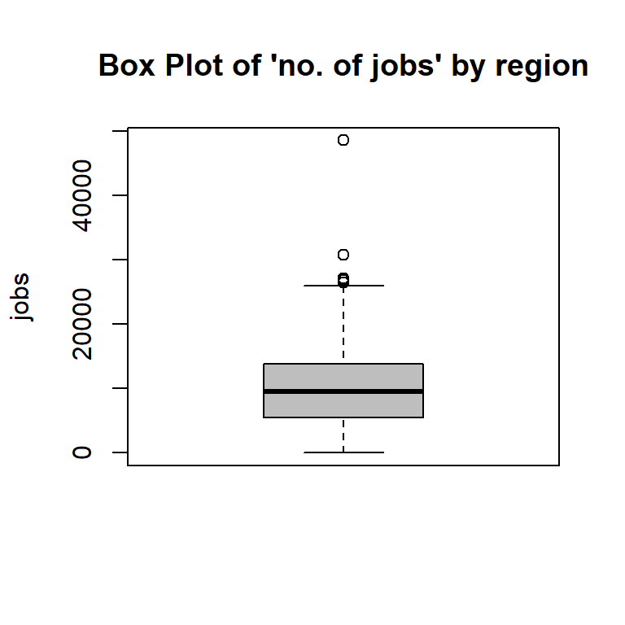

```r
job_boxplot <- boxplot(as.numeric(full_data$`no. of jobs`), main = "Box Plot of 'no. of jobs' by region", ylab = "jobs", col = "grey")
```

* Find the outlier cases by using the z-score method to find when the z score is greater than 3. These are outliers.

```r
z_score_job <- full_data$`no. of jobs` %>% scores(type ="z")
z_score_job %>% summary()
```

```
##
##  13 values imputed to -0.1243648
```

```
##    Min. 1st Qu.  Median    Mean 3rd Qu.    Max.
## -1.7009 -0.7944 -0.1244  0.0000  0.5899  6.3429
```

```r
which(abs(z_score_job) > 3)
```

```
## [1] 348 349
```

- Handling the outliers by capping

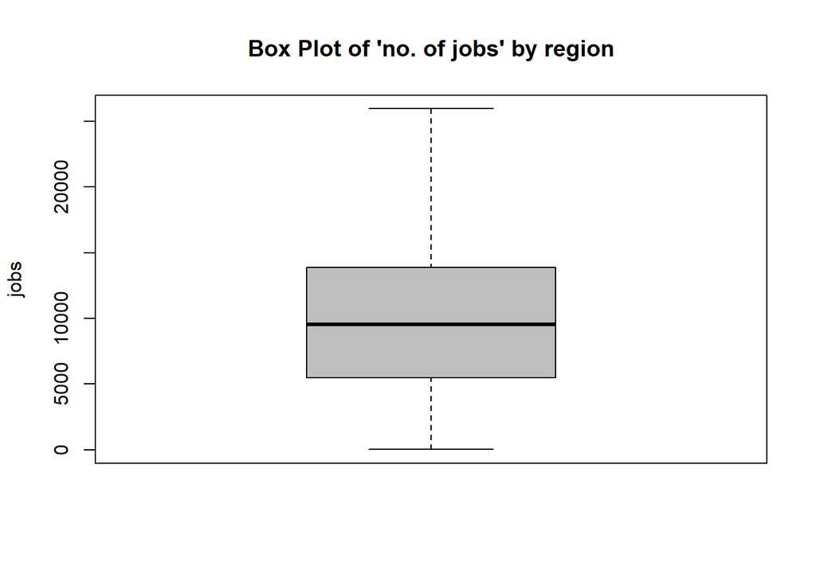

```r
cap <- function(x){
    quantiles <- quantile( x, c(.05, 0.25, 0.75, .95 ) )
    x[ x < quantiles[2] - 1.5*IQR(x) ] <- quantiles[1]
    x[ x > quantiles[3] + 1.5*IQR(x) ] <- quantiles[4]
    x
}

jobs_capped <- full_data$`no. of jobs` %>% cap()
boxplot(as.numeric(jobs_capped), main = "Box Plot of 'no. of jobs' by region", ylab = "jobs", col = "grey")
```

```r
full_data$`no. of jobs` <- jobs_capped
```

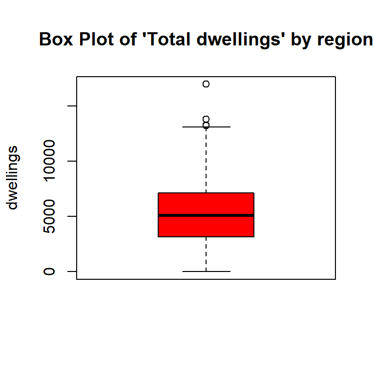

```r
dwellings_boxplot <- boxplot(as.numeric(full_data$`Total dwellings in SA2`), main = "Box Plot of 'Total dwellings' by region", ylab = "dwellings", col = "red")
```

- handle the outliers by capping.

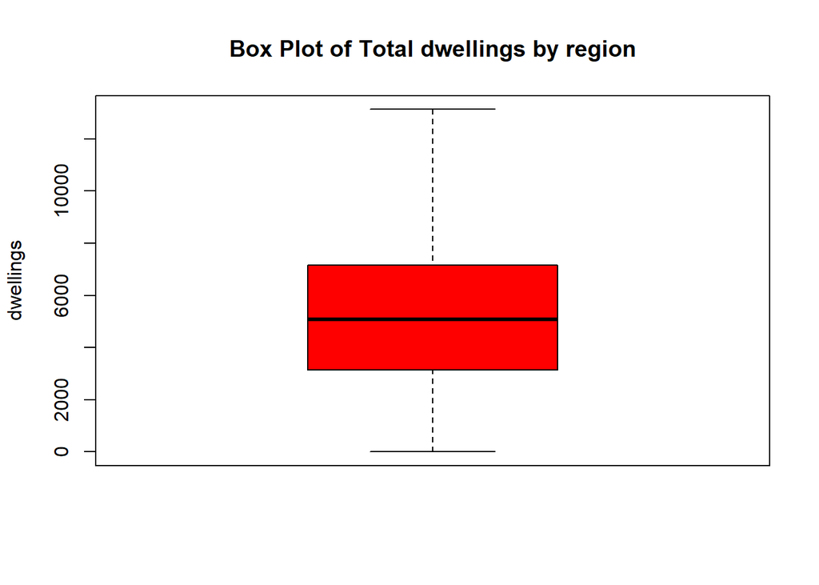

```r
dwellings_capped <- full_data$`Total dwellings in SA2` %>% cap()
boxplot(as.numeric(dwellings_capped), main = "Box Plot of Total dwellings by region", ylab = "dwellings", col = "red")
```

```r
full_data$`Total dwellings in SA2` <- dwellings_capped
```

- Look for multivariate outliers by inspection using a scatterplot.

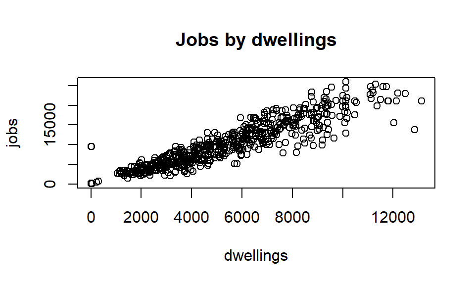

```r
scatter1 <- full_data %>% plot(`no. of jobs`~ `Total dwellings in SA2`, data = ., ylab = "jobs", xlab = "dwellings", main = "Jobs by dwellings")
```

- Look for multivariate outliers with the mvn package which uses the Chi-Square distribution critical value
- Treat by excluding the outliers using “showNewData”
- Jobs vs. total dwellings

```r
class(full_data)
```

```
## [1] "data.frame"
```

```r
colnames(full_data)
```

```
## [1] "SA2 NAME"                        "year"
## [3] "no. of jobs"                     "Income"
## [5] "Total dwellings in SA2"          "Most common mortgage repayments"
## [7] "Repayment reportings"
```

```r
full_data_sub <- full_data %>% dplyr::select(`no. of jobs`, `Total dwellings in SA2`)
job_dwelling_clean <- mvn(data = full_data_sub, multivariateOutlierMethod = "quan", showOutliers = TRUE, showNewData = TRUE)
```

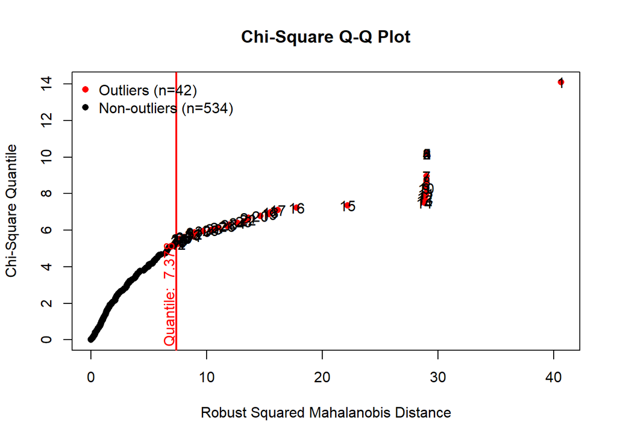

```r
full_data2 <- job_dwelling_clean$newData
head(full_data2)
```

```
##     no. of jobs Total dwellings in SA2
## 100        8760                   4208
## 101       13965                   7486
## 102        6784                   3760
## 103        4690                   2166
## 104        3442                   2037
## 105        4978                   2918
```

*Multivariate outlier #2* income vs jobs

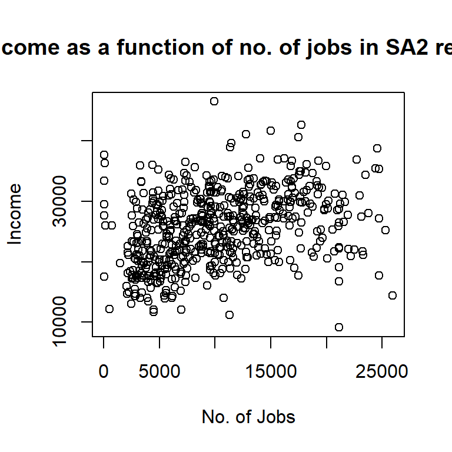

```r
full_data_sub2 <- full_data %>% dplyr::select(`no. of jobs`, Income)
scatplot2 <- full_data %>% plot(Income ~ `no. of jobs`, data = ., ylab = "Income", xlab = "No. of Jobs", main = "Income as a function of no. of jobs in SA2 regions")
```

- Treat mutlivariate outlier

```r
Income_job_clean <- mvn(data = full_data_sub2, multivariateOutlierMethod = "quan", showOutliers = TRUE, showNewData = TRUE)
```

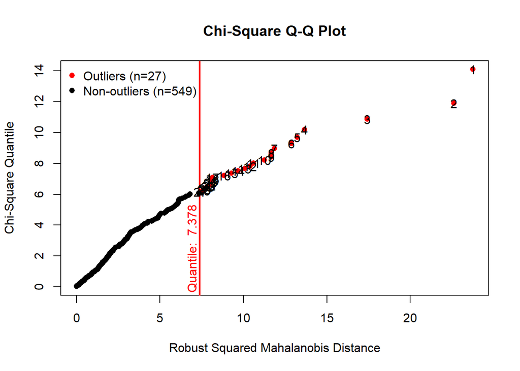

```r
full_data3 <- Income_job_clean$newData
## head(full_data3)  #data suppressed in order ot fit within the page limit of the assignment
```

*Multivariate outlier #3* income vs dwellings

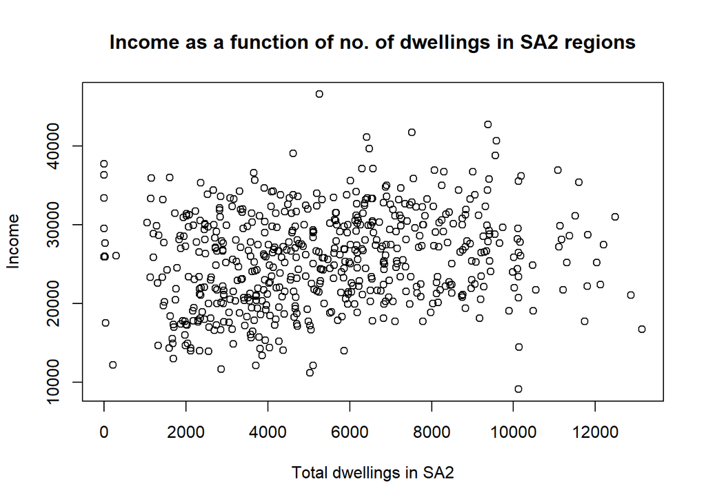

```r
full_data_sub3 <- full_data %>% dplyr::select(`Total dwellings in SA2`, Income)
full_data %>% plot(Income ~ `Total dwellings in SA2`, data = ., ylab = "Income", xlab = "Total dwellings in SA2", main = "Income as a function of no. of dwellings in SA2 regions")
```

```r
Income_dwelling_clean <- mvn(data = full_data_sub3, multivariateOutlierMethod = "quan", showOutliers = TRUE, showNewData = TRUE)
```

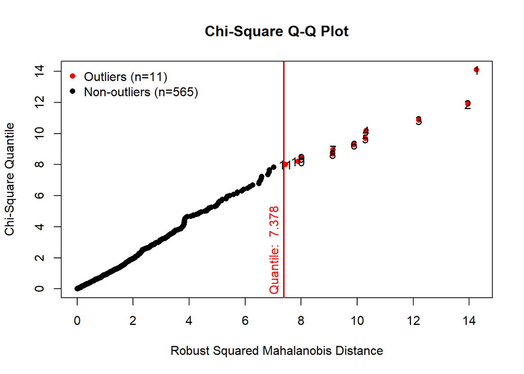

```r
full_data4 <- Income_dwelling_clean$newData
## head(full_data3)  #data suppressed in order ot fit within the page limit of the assignment
```

# Data transformations:

*Histogram of Repayment reporting numbers

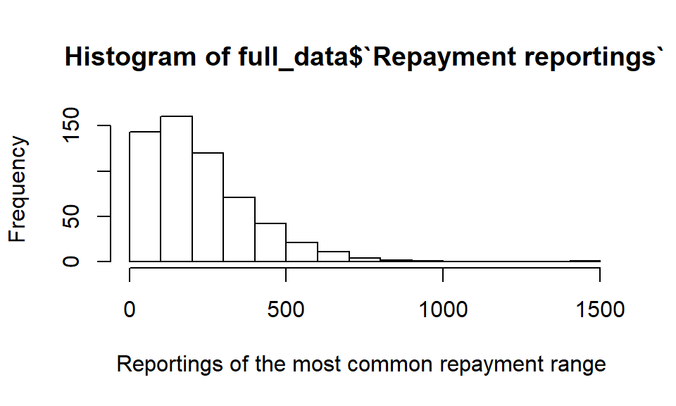

```r
hist <- hist(full_data$`Repayment reportings`, xlab = "Reportings of the most common repayment range ")
```

- The counts of the most common repayment option per region is positively skewed. It would be beneficial to transform the data ,
- BoxCox transformation.
- Use boxcox with lambda set as auto by the package.

```r
boxcox_repaymentfreq <- BoxCox(full_data$`Repayment reportings`, lambda = "auto")
head(boxcox_repaymentfreq)
```

```
## [1]  5.429006  8.324734  8.525332  6.384187 12.353288 10.715659
```

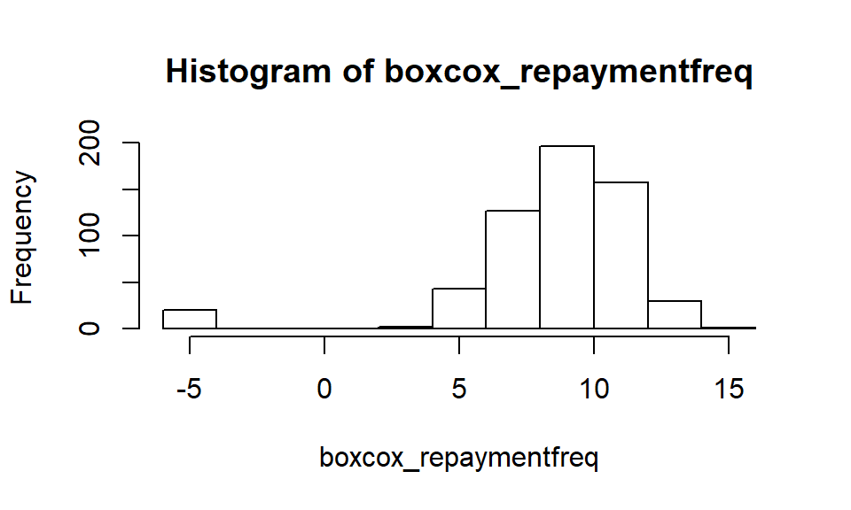

```r
hist(boxcox_repaymentfreq)
```

*log10 transformation* Alternatively use log10 as the shape is positively skewed.

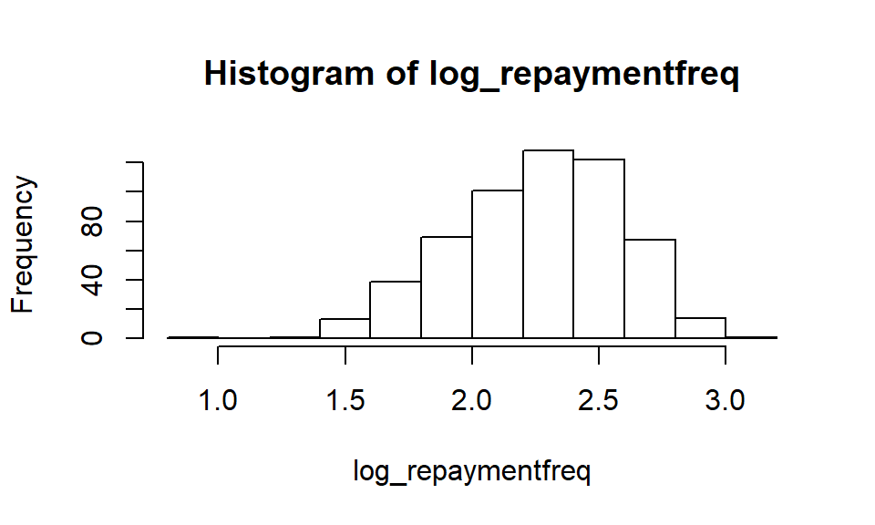

```r
log_repaymentfreq <- log10(full_data$`Repayment reportings`)
hist(log_repaymentfreq)
```